# Proteomic Age Trends of Cross-Modality LR Genes

- Show All Code
- Hide All Code
- View Source

Do the LR genes change with age at protein level? (mouse: Huang 2024; human subfields: Mol 2022)

Published

October 12, 2026

## 1 Overview

Do the genes of the cross-modality LR pairs change with age at the **protein** level?

- **LR pairs:** all significant pairs from `03c` (Visium + scRNA-seq agreement).
- **Mouse proteomics** (`Proteomics_data/Huang_2024`): whole hippocampus, 3 vs 20 months, n = 5 per group, limma statistics from the paper.
- **Human proteomics** (`Proteomics_data/Mol_2022`): 5 subfields (DG, CA1–CA4), age groups 1–10, 21–30, 31–40, 81–90 y; one pooled value per group, so descriptive only.
- All fold changes are **old vs young** (positive = higher in old). Mouse symbols are mapped to human by upper-casing.

```r
library(dplyr)
library(tidyr)
library(ggplot2)
library(readxl)
```

```r
out_dir <- file.path("output", "11_Proteomics_LR_AgeTrends")
dir.create(out_dir, recursive = TRUE, showWarnings = FALSE)

sig_pairs_path  <- file.path("output", "03c_crossModality_plots", "significant_lr_pairs.csv")        # 03c
starmap_pairs_path <- file.path("output", "08_STARmapPLUS_CCC_GenePanelCheck", "sig_pairs_present_starmap.csv")  # 08

huang_path <- file.path("Proteomics_data", "Huang_2024", "pmic13786-sup-0003-tables1-s3.xlsx")
mol_path   <- file.path("Proteomics_data", "Mol_2022", "sj-xlsx-2-omi-10.1089_omi.2022.0053.xlsx")

# DG columns are TMT channels only (no age label); assumed AG1..AG4 like the other sheets
dg_column_order <- c("AG1", "AG2", "AG3", "AG4")

age_labels_human <- c(AG1 = "1-10 y", AG2 = "21-30 y", AG3 = "31-40 y", AG4 = "81-90 y")
```

## 2 LR genes

```r
sig_pairs <- read.csv(sig_pairs_path, stringsAsFactors = FALSE) |>
  mutate(pair_label = paste(ligand_complex, "->", receptor_complex)) |>
  distinct(spatial_pair, pair_label, ligand_complex, receptor_complex)

cat("LR pairs:", n_distinct(sig_pairs$pair_label), "\n")
```

```
LR pairs: 35
```

```r
# split complexes into subunit genes
split_complex <- function(x) unlist(strsplit(x, "_"))

lr_genes <- bind_rows(
  lapply(seq_len(nrow(sig_pairs)), function(i) {
    p <- sig_pairs[i, ]
    bind_rows(
      data.frame(gene = split_complex(p$ligand_complex),   role = "ligand"),
      data.frame(gene = split_complex(p$receptor_complex), role = "receptor")
    ) |> mutate(pair_label = p$pair_label, spatial_pair = p$spatial_pair)
  })
) |>
  distinct()

gene_info <- lr_genes |>
  group_by(gene) |>
  summarise(role          = paste(sort(unique(role)), collapse = "/"),
            pairs         = paste(unique(pair_label), collapse = "; "),
            spatial_pairs = paste(sort(unique(spatial_pair)), collapse = "; "),
            .groups = "drop") |>
  mutate(gene_human = toupper(gene),
         gene_label = paste0(gene, " (", role, ")"))

gene_info
```

| gene | role | pairs | spatial_pairs | gene_human | gene_label |
| --- | --- | --- | --- | --- | --- |
| Ackr3 | receptor | Mif -> Ackr3 | Astrocyte-Vascular | ACKR3 | Ackr3 (receptor) |
| Adam10 | ligand | Adam10 -> Notch2 | Neurogenic_lineage-GC | ADAM10 | Adam10 (ligand) |
| Agrn | ligand | Agrn -> Lrp1 | Vascular-Microglia | AGRN | Agrn (ligand) |
| Aplp1 | receptor | App -> Aplp1 | Astrocyte-Vascular | APLP1 | Aplp1 (receptor) |
| Aplp2 | receptor | App -> Aplp2 | Vascular-Microglia | APLP2 | Aplp2 (receptor) |
| Apoe | ligand | Apoe -> Ldlr; Apoe -> Sorl1 | Astrocyte-Vascular | APOE | Apoe (ligand) |
| App | ligand | App -> Aplp1; App -> Aplp2; App -> Rpsa | Astrocyte-Vascular; Vascular-Microglia | APP | App (ligand) |
| Bsg | ligand | Bsg -> Slc16a7 | Vascular-Microglia | BSG | Bsg (ligand) |
| Calm1 | ligand | Calm1 -> Ptpra | Neurogenic_lineage-GC | CALM1 | Calm1 (ligand) |
| Ccr5 | receptor | Gnai2 -> Ccr5 | Vascular-Microglia | CCR5 | Ccr5 (receptor) |

[output cut: 43 more lines]

## 3 Mouse hippocampus: 20 vs 3 months (Huang et al. 2024)

```r
huang <- read_excel(huang_path, sheet = "Table S1", skip = 2)

# a gene can map to several protein IDs -- keep the most significant entry per gene
huang_genes <- huang |>
  filter(Genename %in% gene_info$gene) |>
  group_by(Genename) |>
  slice_min(adj.P.Val, n = 1, with_ties = FALSE) |>
  ungroup()

cat("LR genes quantified in the mouse proteome:",
    nrow(huang_genes), "/", nrow(gene_info), "\n")
```

```
LR genes quantified in the mouse proteome: 30 / 53
```

```r
missing_mouse <- setdiff(gene_info$gene, huang_genes$Genename)
if (length(missing_mouse) > 0) cat("Not detected:", paste(missing_mouse, collapse = ", "), "\n")
```

```
Not detected: Ackr3, Apoe, Calm1, Ccr5, Cd14, Cxcl12, Igfbpl1, Itga9, Ldlr, Lrp6, Lrp8, Mdk, Notch2, P2ry12, Pdgfa, Pdgfb, Pdgfra, Ptn, Rspo3, Slc16a7, Tlr7, Vegfb, Vtn
```

```r
# the paper's logFC is already old vs young (positive = higher in old)
huang_summary <- huang_genes |>
  transmute(gene = Genename, log2fc_old_vs_young = logFC, AveExpr, P.Value, adj.P.Val) |>
  left_join(gene_info, by = "gene") |>
  mutate(status = case_when(
    adj.P.Val < 0.05 & log2fc_old_vs_young > 0 ~ "higher in old (adj.P < 0.05)",
    adj.P.Val < 0.05 & log2fc_old_vs_young < 0 ~ "lower in old (adj.P < 0.05)",
    TRUE                                       ~ "not significant"
  ))

huang_summary |> select(gene, role, pairs, log2fc_old_vs_young, adj.P.Val, status)
```

| gene | role | pairs | log2fc_old_vs_young | adj.P.Val | status |
| --- | --- | --- | --- | --- | --- |
| Adam10 | ligand | Adam10 -> Notch2 | 0.202899800 | 0.001825140 | higher in old (adj.P < 0.05) |
| Agrn | ligand | Agrn -> Lrp1 | 0.069531224 | 0.216626352 | not significant |
| Aplp1 | receptor | App -> Aplp1 | 0.026111789 | 0.495272891 | not significant |
| Aplp2 | receptor | App -> Aplp2 | -0.078229294 | 0.063167635 | not significant |
| App | ligand | App -> Aplp1; App -> Aplp2; App -> Rpsa | 0.026854961 | 0.372736325 | not significant |
| Bsg | ligand | Bsg -> Slc16a7 | -0.117157514 | 0.018643042 | lower in old (adj.P < 0.05) |
| Cd47 | receptor | Vtn -> Cd47 | -0.300641094 | 0.035540840 | lower in old (adj.P < 0.05) |
| Dcc | receptor | Igfbpl1 -> Dcc | -0.117430654 | 0.010340013 | lower in old (adj.P < 0.05) |
| Efnb2 | ligand | Efnb2 -> Grm5 | -0.048613758 | 0.671842657 | not significant |
| Epha4 | receptor | Fgfr3 -> Epha4 | -0.103087613 | 0.007169956 | lower in old (adj.P < 0.05) |

[output cut: 20 more lines]

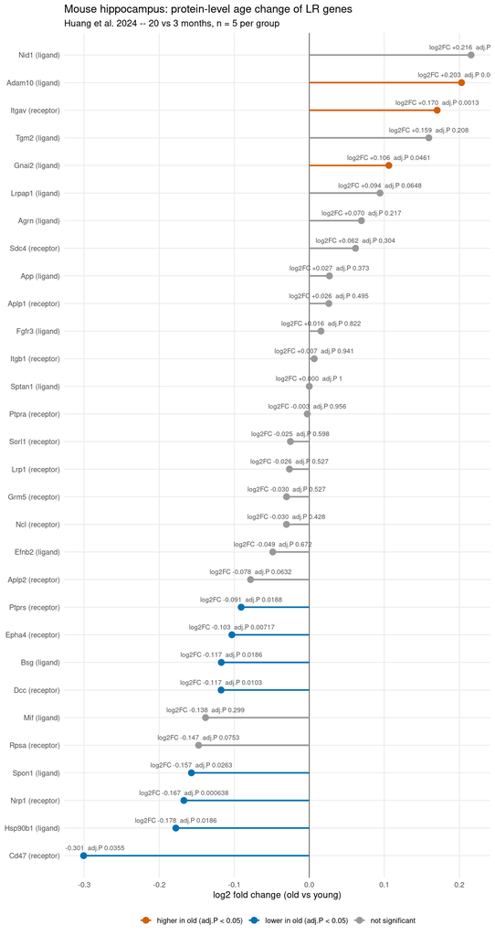

```r
status_colors <- c("higher in old (adj.P < 0.05)" = "#D55E00",
                   "lower in old (adj.P < 0.05)"  = "#0072B2",
                   "not significant"                = "grey60")

ggplot(huang_summary, aes(x = log2fc_old_vs_young,
                          y = reorder(gene_label, log2fc_old_vs_young), color = status)) +
  geom_vline(xintercept = 0, color = "grey40") +
  geom_segment(aes(x = 0, xend = log2fc_old_vs_young,
                   yend = reorder(gene_label, log2fc_old_vs_young)), linewidth = 1) +
  geom_point(size = 3.5) +
  geom_text(aes(label = sprintf("log2FC %+.3f  adj.P %.3g", log2fc_old_vs_young, adj.P.Val)),
            vjust = -1.1, size = 3, color = "grey30") +
  scale_color_manual(values = status_colors, name = NULL) +
  scale_y_discrete(expand = expansion(add = 0.8)) +
  labs(title = "Mouse hippocampus: protein-level age change of LR genes",
       subtitle = "Huang et al. 2024 -- 20 vs 3 months, n = 5 per group",
       x = "log2 fold change (old vs young)", y = NULL) +
  theme_minimal(base_size = 12) +
  theme(legend.position = "bottom", panel.grid.minor = element_blank())
```

Per-sample intensities (5 per group):

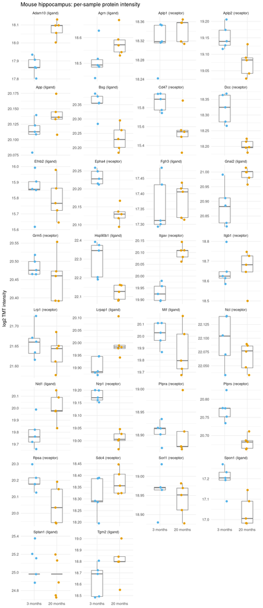

```r
huang_samples <- huang_genes |>
  select(gene = Genename, matches("^(old|young)_\\d+$")) |>
  pivot_longer(-gene, names_to = "sample", values_to = "log2_intensity") |>
  mutate(age = factor(sub("_\\d+$", "", sample), levels = c("young", "old"),
                      labels = c("3 months", "20 months"))) |>
  left_join(gene_info |> select(gene, gene_label), by = "gene")

ggplot(huang_samples, aes(x = age, y = log2_intensity, color = age)) +
  geom_boxplot(outlier.shape = NA, width = 0.5, color = "grey50") +
  geom_point(position = position_jitter(width = 0.1, seed = 1), size = 2) +
  facet_wrap(~ gene_label, scales = "free_y", ncol = 4) +
  scale_color_manual(values = c("3 months" = "#56B4E9", "20 months" = "#E69F00"), guide = "none") +
  labs(title = "Mouse hippocampus: per-sample protein intensity",
       x = NULL, y = "log2 TMT intensity") +
  theme_minimal(base_size = 11)
```

## 4 Human hippocampal subfields across age (Mol et al. 2022)

```r
subfields <- c("DG", "CA4", "CA3", "CA2", "CA1")

# one subfield sheet -> long format; age group parsed from column names (DG: dg_column_order)
read_mol_subfield <- function(sheet) {
  df <- read_excel(mol_path, sheet = sheet, skip = 2)
  abund_cols <- grep("^Abundances", names(df), value = TRUE)
  stopifnot(length(abund_cols) == 4)

  has_label <- grepl("AG?\\s*[1-4]\\s*$", abund_cols)
  age_group <- if (all(has_label)) {
    paste0("AG", sub(".*AG?\\s*([1-4])\\s*$", "\\1", abund_cols))
  } else {
    dg_column_order
  }

  df |>
    select(gene_human = `Gene Symbol`, psms = `# PSMs`, all_of(abund_cols)) |>
    rename_with(~ age_group, all_of(abund_cols)) |>
    filter(gene_human %in% gene_info$gene_human) |>
    # several RefSeq isoforms per gene: keep the best-supported one (most PSMs)
    group_by(gene_human) |>
    slice_max(psms, n = 1, with_ties = FALSE) |>
    ungroup() |>
    pivot_longer(starts_with("AG"), names_to = "age_group", values_to = "abundance") |>
    mutate(subfield = sheet)
}

mol_long <- bind_rows(lapply(subfields, read_mol_subfield)) |>
  mutate(abundance = as.numeric(abundance)) |>
  group_by(subfield, gene_human) |>
  # reference = the youngest group (1-10 y), so each point reads as "this age vs young"
  mutate(log2_vs_AG1 = log2(abundance / abundance[age_group == "AG1"])) |>
  ungroup() |>
  left_join(gene_info |> select(gene, gene_human, gene_label, role), by = "gene_human") |>
  mutate(subfield  = factor(subfield, levels = subfields),
         age_group = factor(age_group, levels = names(age_labels_human)))

detected <- mol_long |> distinct(subfield, gene) |> count(gene, name = "n_subfields")
cat("LR genes detected in at least one human subfield:",
    nrow(detected), "/", nrow(gene_info), "\n")
```

```
LR genes detected in at least one human subfield: 37 / 53
```

```r
missing_human <- setdiff(gene_info$gene, detected$gene)
if (length(missing_human) > 0) cat("Not detected in any subfield:", paste(missing_human, collapse = ", "), "\n")
```

```
Not detected in any subfield: Ackr3, Calm1, Ccr5, Igfbpl1, Itga9, Ldlr, Lrp6, Lrp8, Mdk, Notch2, Pdgfa, Pdgfb, Pdgfra, Rspo3, Tlr7, Vegfb
```

```r
# old (81-90 y) vs young (1-10 y), per subfield
mol_long |>
  filter(age_group == "AG4") |>
  select(gene, subfield, log2_AG4_vs_AG1 = log2_vs_AG1) |>
  pivot_wider(names_from = subfield, values_from = log2_AG4_vs_AG1)
```

| gene | DG | CA4 | CA3 | CA2 | CA1 |
| --- | --- | --- | --- | --- | --- |
| Adam10 | 0.24870944 | 0.32616054 | 0.121813699 | 0.18645631 | 0.304167695 |
| Agrn | 0.13074771 | 0.06587028 | 0.307001803 | 0.06759344 | 0.222590295 |
| Aplp1 | -0.39936986 | -0.37148874 | -0.469043821 | -0.46613785 | -0.170892069 |
| Aplp2 | 0.12442022 | -0.53162347 | 0.261445534 | NA | -0.057787752 |
| Apoe | 0.02225123 | -0.03520319 | -0.069625509 | -0.11001148 | -0.120380092 |
| App | -0.07625713 | 0.04901609 | 0.043607139 | 0.04084117 | -0.004440942 |
| Bsg | 0.06267889 | 0.21512690 | 0.160107408 | -0.01108593 | 0.006993688 |
| Cd14 | -0.58142572 | -0.69962702 | -0.143373477 | -0.21165876 | -0.015758251 |
| Cd47 | 0.82881569 | 0.68413130 | 0.579001612 | 0.58371902 | 0.535665465 |
| Cxcl12 | 0.13651312 | NA | NA | NA | NA |

[output cut: 27 more lines]

One panel per gene:

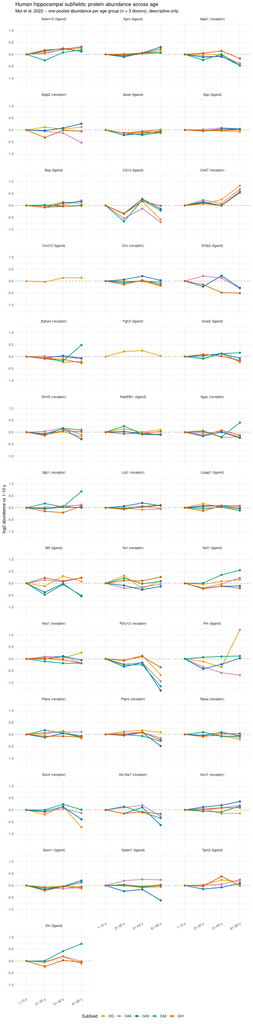

```r
subfield_colors <- c(DG = "#E69F00", CA4 = "#CC79A7", CA3 = "#0072B2", CA2 = "#009E73", CA1 = "#D55E00")

ggplot(mol_long, aes(x = age_group, y = log2_vs_AG1, color = subfield, group = subfield)) +
  geom_hline(yintercept = 0, color = "grey60", linetype = "dashed") +
  geom_line(linewidth = 0.8) +
  geom_point(size = 2) +
  facet_wrap(~ gene_label, ncol = 3) +
  scale_x_discrete(labels = age_labels_human) +
  scale_color_manual(values = subfield_colors, name = "Subfield") +
  labs(title = "Human hippocampal subfields: protein abundance across age",
       subtitle = "Mol et al. 2022 -- one pooled abundance per age group (n = 3 donors), descriptive only",
       x = NULL, y = "log2 abundance vs 1-10 y") +
  theme_minimal(base_size = 11) +
  theme(axis.text.x = element_text(angle = 30, hjust = 1), legend.position = "bottom")
```

One panel per subfield:

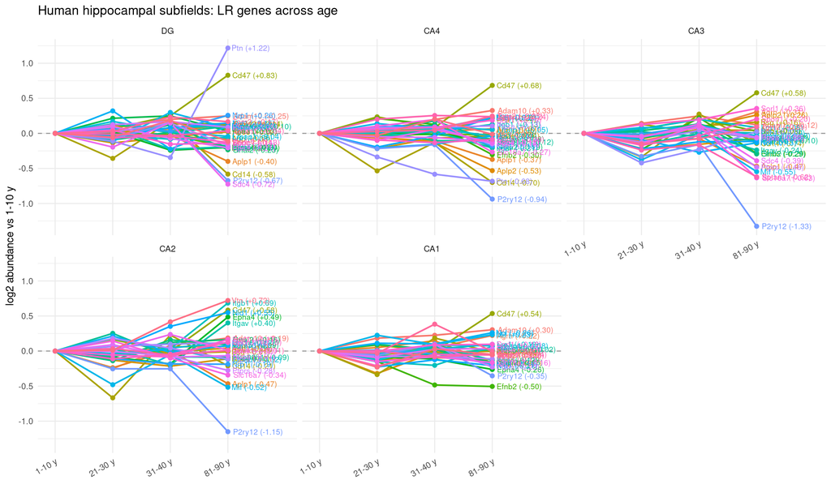

```r
# label each line at the oldest point, with its old-vs-young value
end_labels <- mol_long |> filter(age_group == "AG4")

ggplot(mol_long, aes(x = age_group, y = log2_vs_AG1, color = gene, group = gene)) +
  geom_hline(yintercept = 0, color = "grey60", linetype = "dashed") +
  geom_line(linewidth = 0.8) +
  geom_point(size = 1.8) +
  geom_text(data = end_labels, aes(label = sprintf("%s (%+.2f)", gene, log2_vs_AG1)),
            hjust = -0.1, size = 2.8, show.legend = FALSE) +
  facet_wrap(~ subfield, ncol = 3) +
  scale_x_discrete(labels = age_labels_human, expand = expansion(add = c(0.3, 1.2))) +
  labs(title = "Human hippocampal subfields: LR genes across age",
       x = NULL, y = "log2 abundance vs 1-10 y", color = NULL) +
  theme_minimal(base_size = 11) +
  theme(axis.text.x = element_text(angle = 30, hjust = 1), legend.position = "bottom") +
  guides(color = "none")
```

## 5 Mouse and human side by side

Old vs young: mouse 20 vs 3 months (`*` = adj.P < 0.05) and each human subfield 81–90 vs 1–10 y. Orange = higher in old; grey = not detected.

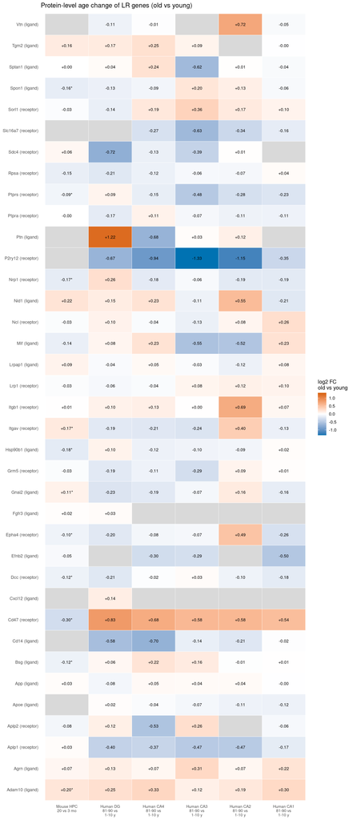

```r
combined <- bind_rows(
  huang_summary |>
    transmute(gene, gene_label, dataset = "Mouse HPC\n20 vs 3 mo", log2fc = log2fc_old_vs_young,
              star = ifelse(adj.P.Val < 0.05, "*", "")),
  mol_long |>
    filter(age_group == "AG4") |>
    transmute(gene, gene_label, dataset = paste0("Human ", subfield, "\n81-90 vs\n1-10 y"),
              log2fc = log2_vs_AG1, star = "")
) |>
  complete(nesting(gene, gene_label), dataset) |>
  mutate(dataset = factor(dataset, levels = c("Mouse HPC\n20 vs 3 mo",
                                              paste0("Human ", subfields, "\n81-90 vs\n1-10 y"))))

lim <- max(abs(combined$log2fc), na.rm = TRUE)

ggplot(combined, aes(x = dataset, y = gene_label, fill = log2fc)) +
  geom_tile(color = "white") +
  geom_text(aes(label = ifelse(is.na(log2fc), "", sprintf("%+.2f%s", log2fc, star))), size = 3) +
  scale_fill_gradient2(low = "#0072B2", mid = "white", high = "#D55E00",
                       limits = c(-lim, lim), na.value = "grey85", name = "log2 FC\nold vs young") +
  labs(title = "Protein-level age change of LR genes (old vs young)", x = NULL, y = NULL) +
  theme_minimal(base_size = 11) +
  theme(panel.grid = element_blank(), axis.text.x = element_text(size = 8, lineheight = 0.9))
```

```r
write.csv(combined |> mutate(dataset = gsub("\n", " ", dataset)),
          file.path(out_dir, "lr_genes_protein_age_change.csv"), row.names = FALSE)
```

## 6 LR genes on the STARmap PLUS panel

Same plots as above, restricted to the genes of the LR pairs that `08` found on the STARmap PLUS panel (the pairs tested in `09`/`10` and `09b`/`10b`).

```r
starmap_pairs <- read.csv(starmap_pairs_path, stringsAsFactors = FALSE) |>
  mutate(pair_label = paste(ligand_complex, "->", receptor_complex)) |>
  distinct(pair_label, ligand_complex, receptor_complex)

starmap_genes <- unique(c(split_complex(starmap_pairs$ligand_complex),
                          split_complex(starmap_pairs$receptor_complex)))

gene_info_sp     <- gene_info     |> filter(gene %in% starmap_genes)
huang_summary_sp <- huang_summary |> filter(gene %in% starmap_genes)
huang_samples_sp <- huang_samples |> filter(gene %in% starmap_genes)
mol_long_sp      <- mol_long      |> filter(gene %in% starmap_genes)
combined_sp      <- combined      |> filter(gene %in% starmap_genes)

cat("STARmap panel LR pairs:", nrow(starmap_pairs), "| genes:", length(starmap_genes),
    "| in mouse proteome:", nrow(huang_summary_sp),
    "| in >= 1 human subfield:", n_distinct(mol_long_sp$gene), "\n")
```

```
STARmap panel LR pairs: 13 | genes: 24 | in mouse proteome: 14 | in >= 1 human subfield: 19
```

```r
gene_info_sp
```

| gene | role | pairs | spatial_pairs | gene_human | gene_label |
| --- | --- | --- | --- | --- | --- |
| Adam10 | ligand | Adam10 -> Notch2 | Neurogenic_lineage-GC | ADAM10 | Adam10 (ligand) |
| Aplp1 | receptor | App -> Aplp1 | Astrocyte-Vascular | APLP1 | Aplp1 (receptor) |
| Apoe | ligand | Apoe -> Ldlr; Apoe -> Sorl1 | Astrocyte-Vascular | APOE | Apoe (ligand) |
| App | ligand | App -> Aplp1; App -> Aplp2; App -> Rpsa | Astrocyte-Vascular; Vascular-Microglia | APP | App (ligand) |
| Bsg | ligand | Bsg -> Slc16a7 | Vascular-Microglia | BSG | Bsg (ligand) |
| Calm1 | ligand | Calm1 -> Ptpra | Neurogenic_lineage-GC | CALM1 | Calm1 (ligand) |
| Cd14 | ligand | Cd14 -> Itgb1 | Vascular-Microglia | CD14 | Cd14 (ligand) |
| Cxcl12 | ligand | Cxcl12 -> Itgb1; Cxcl12 -> Itgav | Astrocyte-Vascular; OPC-Cajal.Retzius; Vascular-Microglia | CXCL12 | Cxcl12 (ligand) |
| Dcc | receptor | Igfbpl1 -> Dcc | Neurogenic_lineage-GC | DCC | Dcc (receptor) |
| Efnb2 | ligand | Efnb2 -> Grm5 | OPC-Cajal.Retzius | EFNB2 | Efnb2 (ligand) |

[output cut: 14 more lines]

### 6.1 Mouse hippocampus (Huang et al. 2024)

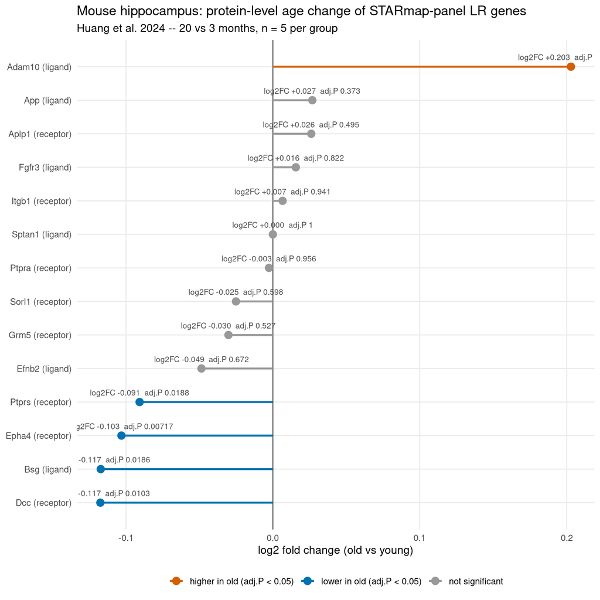

```r
ggplot(huang_summary_sp, aes(x = log2fc_old_vs_young,
                             y = reorder(gene_label, log2fc_old_vs_young), color = status)) +
  geom_vline(xintercept = 0, color = "grey40") +
  geom_segment(aes(x = 0, xend = log2fc_old_vs_young,
                   yend = reorder(gene_label, log2fc_old_vs_young)), linewidth = 1) +
  geom_point(size = 3.5) +
  geom_text(aes(label = sprintf("log2FC %+.3f  adj.P %.3g", log2fc_old_vs_young, adj.P.Val)),
            vjust = -1.1, size = 3, color = "grey30") +
  scale_color_manual(values = status_colors, name = NULL) +
  scale_y_discrete(expand = expansion(add = 0.8)) +
  labs(title = "Mouse hippocampus: protein-level age change of STARmap-panel LR genes",
       subtitle = "Huang et al. 2024 -- 20 vs 3 months, n = 5 per group",
       x = "log2 fold change (old vs young)", y = NULL) +
  theme_minimal(base_size = 12) +
  theme(legend.position = "bottom", panel.grid.minor = element_blank())
```

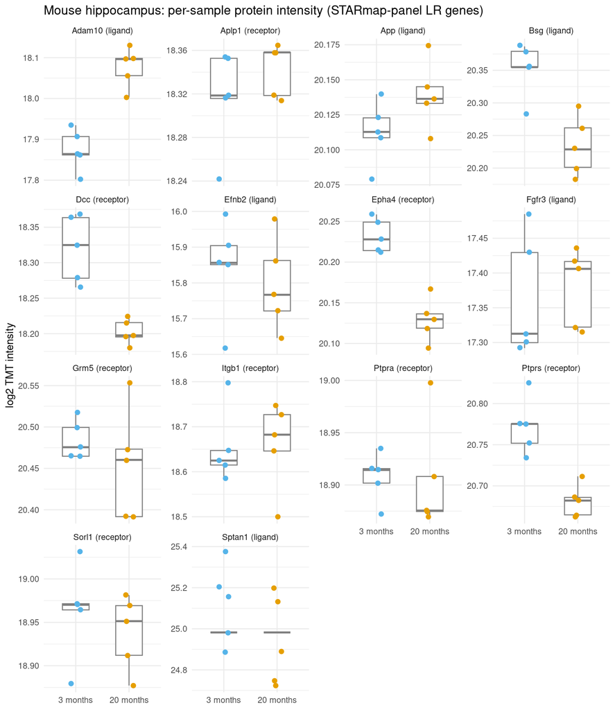

```r
ggplot(huang_samples_sp, aes(x = age, y = log2_intensity, color = age)) +
  geom_boxplot(outlier.shape = NA, width = 0.5, color = "grey50") +
  geom_point(position = position_jitter(width = 0.1, seed = 1), size = 2) +
  facet_wrap(~ gene_label, scales = "free_y", ncol = 4) +
  scale_color_manual(values = c("3 months" = "#56B4E9", "20 months" = "#E69F00"), guide = "none") +
  labs(title = "Mouse hippocampus: per-sample protein intensity (STARmap-panel LR genes)",
       x = NULL, y = "log2 TMT intensity") +
  theme_minimal(base_size = 11)
```

### 6.2 Human hippocampal subfields (Mol et al. 2022)

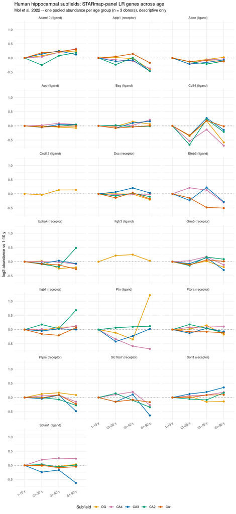

```r
ggplot(mol_long_sp, aes(x = age_group, y = log2_vs_AG1, color = subfield, group = subfield)) +
  geom_hline(yintercept = 0, color = "grey60", linetype = "dashed") +
  geom_line(linewidth = 0.8) +
  geom_point(size = 2) +
  facet_wrap(~ gene_label, ncol = 3) +
  scale_x_discrete(labels = age_labels_human) +
  scale_color_manual(values = subfield_colors, name = "Subfield") +
  labs(title = "Human hippocampal subfields: STARmap-panel LR genes across age",
       subtitle = "Mol et al. 2022 -- one pooled abundance per age group (n = 3 donors), descriptive only",
       x = NULL, y = "log2 abundance vs 1-10 y") +
  theme_minimal(base_size = 11) +
  theme(axis.text.x = element_text(angle = 30, hjust = 1), legend.position = "bottom")
```

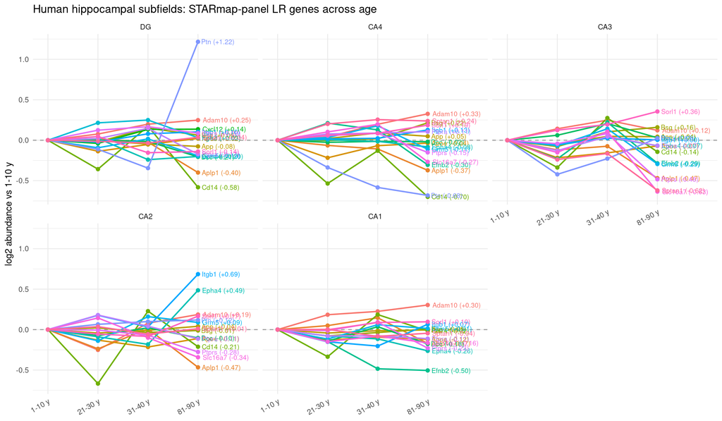

```r
end_labels_sp <- mol_long_sp |> filter(age_group == "AG4")

ggplot(mol_long_sp, aes(x = age_group, y = log2_vs_AG1, color = gene, group = gene)) +
  geom_hline(yintercept = 0, color = "grey60", linetype = "dashed") +
  geom_line(linewidth = 0.8) +
  geom_point(size = 1.8) +
  geom_text(data = end_labels_sp, aes(label = sprintf("%s (%+.2f)", gene, log2_vs_AG1)),
            hjust = -0.1, size = 2.8, show.legend = FALSE) +
  facet_wrap(~ subfield, ncol = 3) +
  scale_x_discrete(labels = age_labels_human, expand = expansion(add = c(0.3, 1.2))) +
  labs(title = "Human hippocampal subfields: STARmap-panel LR genes across age",
       x = NULL, y = "log2 abundance vs 1-10 y", color = NULL) +
  theme_minimal(base_size = 11) +
  theme(axis.text.x = element_text(angle = 30, hjust = 1), legend.position = "bottom") +
  guides(color = "none")
```

### 6.3 Mouse and human side by side

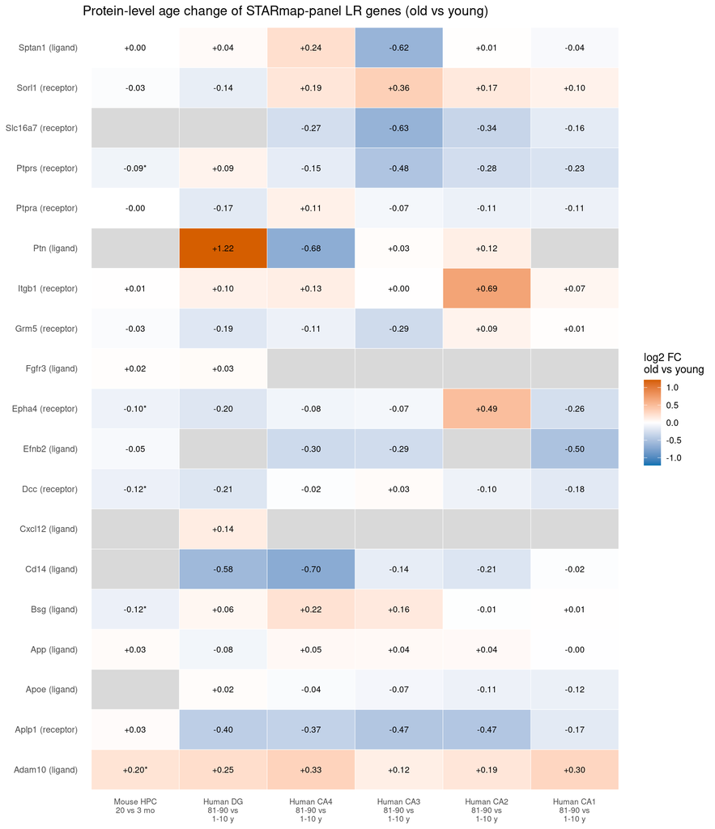

```r
lim_sp <- max(abs(combined_sp$log2fc), na.rm = TRUE)

ggplot(combined_sp, aes(x = dataset, y = gene_label, fill = log2fc)) +
  geom_tile(color = "white") +
  geom_text(aes(label = ifelse(is.na(log2fc), "", sprintf("%+.2f%s", log2fc, star))), size = 3) +
  scale_fill_gradient2(low = "#0072B2", mid = "white", high = "#D55E00",
                       limits = c(-lim_sp, lim_sp), na.value = "grey85", name = "log2 FC\nold vs young") +
  labs(title = "Protein-level age change of STARmap-panel LR genes (old vs young)", x = NULL, y = NULL) +
  theme_minimal(base_size = 11) +
  theme(panel.grid = element_blank(), axis.text.x = element_text(size = 8, lineheight = 0.9))
```

```r
write.csv(combined_sp |> mutate(dataset = gsub("\n", " ", dataset)),
          file.path(out_dir, "lr_genes_protein_age_change_starmap_panel.csv"), row.names = FALSE)
```

## 7 Distribution of fold changes across all proteins

Old vs young log2 fold change for **every** quantified protein, to see how large the LR-gene changes are compared with the whole proteome. Dashed lines = LR genes (all `03c` pairs); the text gives where the LR genes fall in each distribution.

```r
huang_all <- huang |>
  filter(!is.na(logFC)) |>
  group_by(Genename) |>
  slice_min(adj.P.Val, n = 1, with_ties = FALSE) |>
  ungroup() |>
  mutate(is_lr = Genename %in% gene_info$gene)

q_mouse <- quantile(huang_all$logFC, c(0.025, 0.5, 0.975), na.rm = TRUE)
cat(sprintf("Mouse: %d proteins | median log2FC %+.3f | central 95%%: [%+.3f, %+.3f] | adj.P < 0.05: %d\n",
            nrow(huang_all), q_mouse[2], q_mouse[1], q_mouse[3], sum(huang_all$adj.P.Val < 0.05, na.rm = TRUE)))
```

```
Mouse: 5598 proteins | median log2FC -0.015 | central 95%: [-0.213, +0.288] | adj.P < 0.05: 1140
```

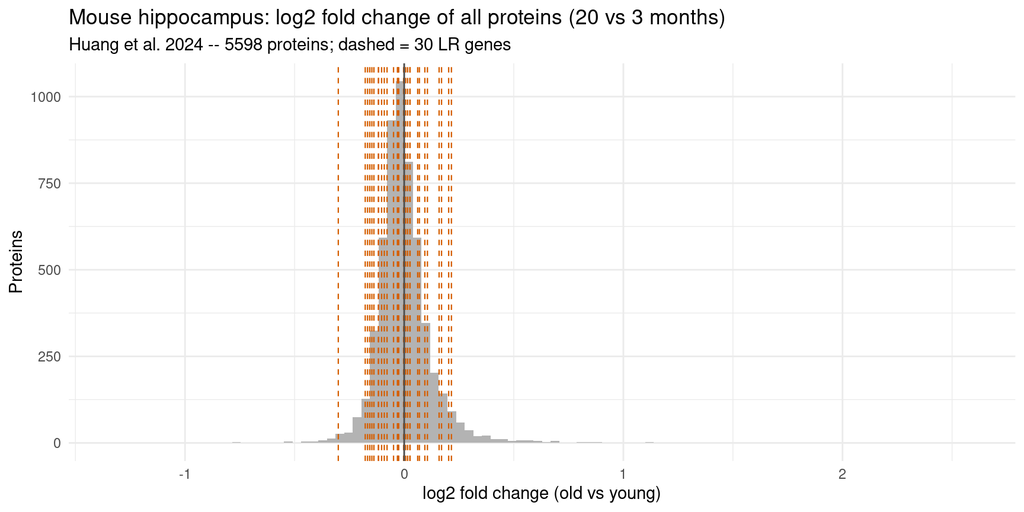

```r
ggplot(huang_all, aes(x = logFC)) +
  geom_histogram(bins = 100, fill = "grey70", color = NA) +
  geom_vline(data = filter(huang_all, is_lr), aes(xintercept = logFC),
             color = "#D55E00", linetype = "dashed", linewidth = 0.4) +
  geom_vline(xintercept = 0, color = "grey30") +
  labs(title = "Mouse hippocampus: log2 fold change of all proteins (20 vs 3 months)",
       subtitle = sprintf("Huang et al. 2024 -- %d proteins; dashed = %d LR genes",
                          nrow(huang_all), sum(huang_all$is_lr)),
       x = "log2 fold change (old vs young)", y = "Proteins") +
  theme_minimal(base_size = 11)
```

```r
# same parsing as read_mol_subfield(), without restricting to the LR genes
read_mol_subfield_all <- function(sheet) {
  df <- read_excel(mol_path, sheet = sheet, skip = 2)
  abund_cols <- grep("^Abundances", names(df), value = TRUE)
  has_label <- grepl("AG?\\s*[1-4]\\s*$", abund_cols)
  age_group <- if (all(has_label)) paste0("AG", sub(".*AG?\\s*([1-4])\\s*$", "\\1", abund_cols)) else dg_column_order

  df |>
    select(gene_human = `Gene Symbol`, psms = `# PSMs`, all_of(abund_cols)) |>
    rename_with(~ age_group, all_of(abund_cols)) |>
    filter(!is.na(gene_human)) |>
    group_by(gene_human) |>
    slice_max(psms, n = 1, with_ties = FALSE) |>
    ungroup() |>
    mutate(AG1 = as.numeric(AG1), AG4 = as.numeric(AG4),
           log2fc = log2(AG4 / AG1), subfield = sheet) |>
    filter(is.finite(log2fc)) |>
    select(subfield, gene_human, log2fc)
}

mol_all <- bind_rows(lapply(subfields, read_mol_subfield_all)) |>
  mutate(subfield = factor(subfield, levels = subfields),
         is_lr = gene_human %in% gene_info$gene_human)

mol_all |>
  group_by(subfield) |>
  summarise(n_proteins = n(),
            median = median(log2fc),
            q025 = quantile(log2fc, 0.025), q975 = quantile(log2fc, 0.975),
            n_lr = sum(is_lr), .groups = "drop") |>
  mutate(across(c(median, q025, q975), ~ round(.x, 3)))
```

| subfield | n_proteins | median | q025 | q975 | n_lr |
| --- | --- | --- | --- | --- | --- |
| DG | 5551 | -0.060 | -0.537 | 0.667 | 35 |
| CA4 | 5326 | -0.032 | -0.572 | 0.606 | 35 |
| CA3 | 5255 | -0.050 | -0.600 | 0.683 | 34 |
| CA2 | 4120 | -0.075 | -0.742 | 0.735 | 32 |
| CA1 | 4619 | -0.019 | -0.556 | 0.674 | 33 |

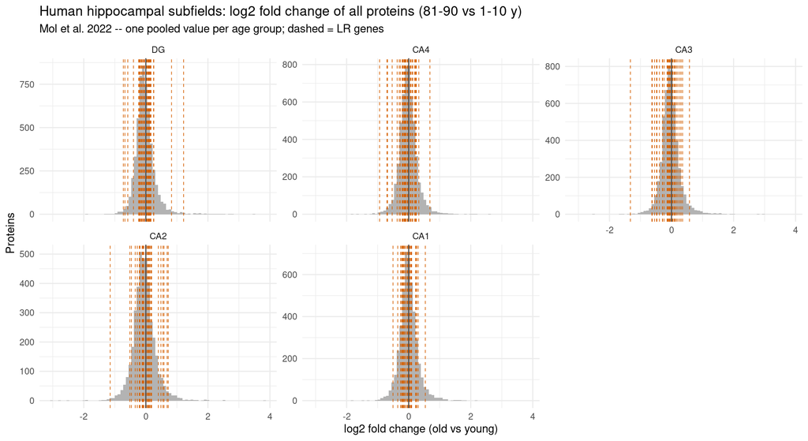

```r
ggplot(mol_all, aes(x = log2fc)) +
  geom_histogram(bins = 80, fill = "grey70", color = NA) +
  geom_vline(data = filter(mol_all, is_lr), aes(xintercept = log2fc),
             color = "#D55E00", linetype = "dashed", linewidth = 0.3) +
  geom_vline(xintercept = 0, color = "grey30") +
  facet_wrap(~ subfield, ncol = 3, scales = "free_y") +
  labs(title = "Human hippocampal subfields: log2 fold change of all proteins (81-90 vs 1-10 y)",
       subtitle = "Mol et al. 2022 -- one pooled value per age group; dashed = LR genes",
       x = "log2 fold change (old vs young)", y = "Proteins") +
  theme_minimal(base_size = 11)
```

Where the LR genes sit in each distribution (percentile of their log2FC among all proteins; 50 = typical, near 0 or 100 = among the largest changes):

```r
lr_percentiles <- bind_rows(
  huang_all |>
    mutate(percentile = round(100 * rank(logFC) / n(), 1)) |>
    filter(is_lr) |>
    transmute(gene = Genename, dataset = "Mouse HPC", log2fc = logFC, percentile),
  mol_all |>
    group_by(subfield) |>
    mutate(percentile = round(100 * rank(log2fc) / n(), 1)) |>
    ungroup() |>
    filter(is_lr) |>
    left_join(gene_info |> select(gene, gene_human), by = "gene_human") |>
    transmute(gene, dataset = paste("Human", subfield), log2fc, percentile)
)

lr_percentiles |>
  select(-log2fc) |>
  pivot_wider(names_from = dataset, values_from = percentile) |>
  arrange(gene)
```

| gene | Mouse HPC | Human DG | Human CA4 | Human CA3 | Human CA2 | Human CA1 |
| --- | --- | --- | --- | --- | --- | --- |
| Adam10 | 94.9 | 86.9 | 91.0 | 76.6 | 80.4 | 88.5 |
| Agrn | 79.9 | 77.6 | 65.8 | 90.3 | 68.9 | 82.6 |
| Aplp1 | 67.2 | 7.3 | 8.1 | 5.1 | 9.1 | 25.0 |
| Aplp2 | 21.6 | 77.0 | 3.1 | 87.9 | NA | 43.2 |
| Apoe | NA | 63.2 | 49.4 | 46.1 | 45.1 | 32.2 |
| App | 67.5 | 46.8 | 63.6 | 66.3 | 65.5 | 52.4 |
| Bsg | 11.2 | 69.3 | 83.9 | 80.6 | 58.1 | 54.5 |
| Cd14 | NA | 1.9 | 1.2 | 33.7 | 30.7 | 50.5 |
| Cd47 | 1.0 | 98.4 | 98.2 | 96.6 | 95.8 | 95.8 |
| Cxcl12 | NA | 78.2 | NA | NA | NA | NA |

[output cut: 27 more lines]

```r
write.csv(lr_percentiles, file.path(out_dir, "lr_genes_log2fc_percentile_vs_all_proteins.csv"), row.names = FALSE)
```

## 8 Notes

- Moran’s I measures spatial co-variation of a pair; proteomics measures the amount of one protein. Agreement in direction is supportive, not confirmation.
- Human data: one pooled value per age group, trends only.
- Both datasets are bulk tissue: no cell-type attribution.